# P337: Correlation of gene modules with donor outcomes

Kim Dill-McFarland, kadm@uw.edu

version September 12, 2022

# Background

The purpose of this workflow is to associate gene module expression (EOS, NEUT) with host outcomes including:

- fMRI
- Lung function / asthma
- Protein

# Setup

Load packages

```r
# Data manipulation and figures
library(tidyverse)
library(readxl)
library(tidytext)
# RNAseq data
library(limma)
#Correlation
library(corrplot)
#PLS
library(mixOmics)
##  Be careful of version as this package if often not back compatible
#Enrichment MSigDB
library(SEARchways)
# Print pretty table to knit file
library(knitr)
library(kableExtra)
options(knitr.kable.NA = '')

`%notin%` <- Negate(`%in%`)
```

Set seed

```r
set.seed(4389)
```

Load functions

```r
source("scripts/corr.fxn.R")
```

# Load data

```r
load("data_clean/P337_BAL_data.RData")
```

# Format data

## Calculate V5 - V4

When applicable, correlations will be completed for delta values (V5-V4) to capture the paired nature of these data.

#### Module expression

Two donors are removed from BE expression data (MA1001 missing V4, MA1086 missing V5).

```r
#Read in all module expression
mod.files <- list.files(path="results/module_level/", pattern="mod_voom_counts",
                        recursive = TRUE, full.names = TRUE)

counts.mod <- data.frame()
for(file in mod.files){
  counts.temp <- read_csv(file) %>%
    pivot_longer(-c(module,module.char), names_to="libID")

  counts.mod <- rbind(counts.mod, counts.temp)
}

#Calculate delta
counts.mod.delta <- counts.mod %>%
  #Remove modules 00
  filter(!grepl("_00",module)) %>%
  dplyr::select(-module.char) %>%
  #Add metadata to denote V4, V5
  full_join(dplyr::select(dat.BAL.abund.norm.voom$targets,
                   libID, donorID, visit), by = "libID") %>%
  #separate V4 and V5
  dplyr::select(-libID) %>%
  pivot_wider(names_from = visit) %>%
  mutate(delta = V5-V4) %>%
  #shorten module names
  mutate(module=gsub("module_P337_", "", module)) %>%
  #wide format
  dplyr::select(-V4,-V5) %>%
  arrange(donorID, module) %>%
  pivot_wider(names_from = module, values_from = delta)
```

#### Cytokine protein

```r
plex.delta <- read_csv("data_raw/addtl.data/P337_BAL.multiplex.csv") %>%
  rename(donorID=ptID, FGF2_V4=TGF2_V4) %>%
  pivot_longer(-donorID) %>%
  #Log10 transform
  mutate(value = log10(value)) %>%
  separate(name, into=c("name","visit"), sep="_") %>%
  pivot_wider(names_from = visit) %>%
  mutate(delta = V5-V4) %>%
  drop_na(delta) %>%
  dplyr::select(-V4,-V5) %>%
  arrange(name) %>%
  mutate(name = paste(name, "multiplex", sep=".")) %>%
  pivot_wider(values_from = delta)
```

Check if cytokine genes are in expression modules as well.

| Module | Gene HGNC | Cytokine |
| --- | --- | --- |
| EOS_01 | CCL13 | CCL13 |
| EOS_01 | CCL2 | CCL2 |
| EOS_01 | CCL22 | CCL22 |
| EOS_01 | CCL26 | CCL26 |
| EOS_01 | CCL7 | CCL7 |
| EOS_01 | CXCL8 | IL8 |
| EOS_01 | CCL17 | TARC |
| EOS_01 | TGFA | TGFA |
| EOS_02 | FLT3LG | FLT3L |
| EOS_02 | IL10 | IL10 |
| EOS_02 | IL9 | IL9 |
| EOS_02 | VEGFA | VEGF |
| EOS_04 | IL16 | IL16 |
| EOS_05 | IL1RN | IL1RA |
| EOS_06 | CCL8 | CCL8 |
| EOS_06 | CXCL1 | CXCL1 |
| EOS_06 | IL13 | IL13 |
| EOS_06 | IL6 | IL6 |
| EOS_06 | CD40LG | sCD40L |
| NEUT_01 | CCL13 | CCL13 |
| NEUT_01 | CCL2 | CCL2 |
| NEUT_01 | CCL7 | CCL7 |
| NEUT_01 | CCL8 | CCL8 |
| NEUT_01 | CXCL1 | CXCL1 |
| NEUT_01 | IL10 | IL10 |
| NEUT_01 | IL6 | IL6 |
| NEUT_01 | CXCL8 | IL8 |
| NEUT_01 | VEGFA | VEGF |

#### fMRI

Donor MA1012 is removed due to movement issues in fMRI.

```r
#Time point 1 = visit 4
neuro <- read_excel(sheet="T1",
  "data_raw/addtl.data/extraced.clusters.Matt.Altman_wbaseline_psychdata.xlsx") %>%
  #long format
  pivot_longer(-idnum, names_to="neuro") %>%
  #add visit variable
  mutate(visit="V4")

#Time point 2 = visit 5
neuro <- read_excel(sheet="T2",
  "data_raw/addtl.data/extraced.clusters.Matt.Altman_wbaseline_psychdata.xlsx") %>%
  #long format
  pivot_longer(-idnum, names_to="neuro") %>%
  #add visit variable
  mutate(visit="V5") %>%
  #Combine with other visit
  full_join(neuro) %>%
  #Format idnum to match RNAseq data
  mutate(idnum = paste("MA",idnum, sep="")) %>%
  rename(donorID=idnum)

neuro.delta <- neuro %>%
  filter(donorID != "MA1012" & neuro != "LSI" & neuro != "BDI") %>%
  #Calculate delta
  pivot_wider(names_from = visit) %>%
  mutate(delta = V5-V4) %>%
  #remove fxnal metrics
  filter(!grepl("3way",neuro) & !grepl("LPR", neuro)) %>%
  #fix name
  mutate(neuro = gsub("amgy","amyg",neuro)) %>%
  #wide format
  dplyr::select(-V4,-V5) %>%
  pivot_wider(names_from = neuro, values_from = delta)
```

# Partial least squares (PLS)

Regression mode: Y matrix is deflated with respect to information extracted/modeled from local regression on X. Here, the goal is to predict Y from X (and vice versa).

Sparse: simultaneous variable selection in X and Y with LASSO penalization on each pair of loading vectors

http://mixomics.org/methods/spls/

## fMRI ~ module expression + cytokine protein

Format data

```r
X <- counts.mod.delta %>%
  filter(donorID %in% neuro.delta$donorID) %>%
  rename_all(~gsub(".pct","",.)) %>%
  rename_all(~gsub("_"," ",.)) %>%
  full_join(plex.delta) %>%
  rename_all(~gsub(".multiplex","",.)) %>%
  column_to_rownames("donorID")
X <- X[complete.cases(X),]

Y <- neuro.delta %>%
  filter(donorID %in% rownames(X)) %>%
  rename_all(~gsub("_"," ",.)) %>%
  column_to_rownames("donorID")

##Check order
identical(rownames(X),rownames(Y))
```

```
## [1] TRUE
```

Perform SPLS regression.

```r
ncomp = 10
#SPLS
spls <- spls(X, Y, ncomp = ncomp, mode = "regression")
```

### Tuning

#### Number of components

Compute evaluation criteria for SPLS.

```r
spls.Q2 <- perf(spls, validation = "Mfold", folds = 10, nrepeat = 100,
                progressBar = FALSE)
```

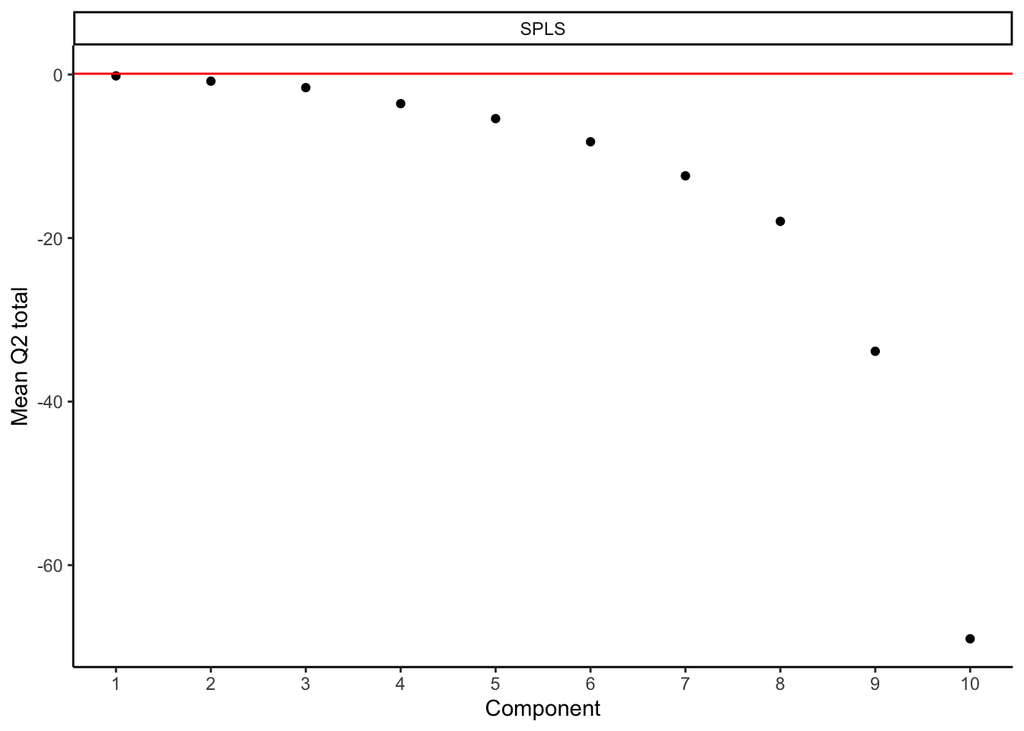

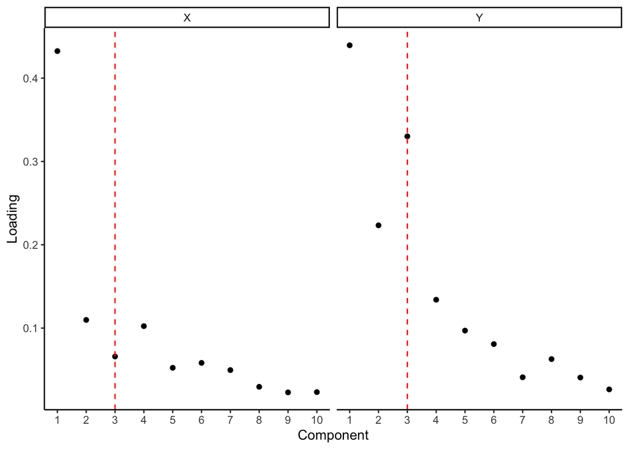

Taken together, 3 X and 3 Y components will be assessed, though likely only 2 components will be used in the final model.

#### Number of variables

Compute error and fit metrics for variables on each component. The goal is to minimize error while maximizing correlation.

- mean average error (MAE): average magnitude of absolute model error
- bias: average difference between Y predictions and actual Y observations

##### X-variables

Tuning suggests about 20 variables on component 1 and all 64 on component 2.

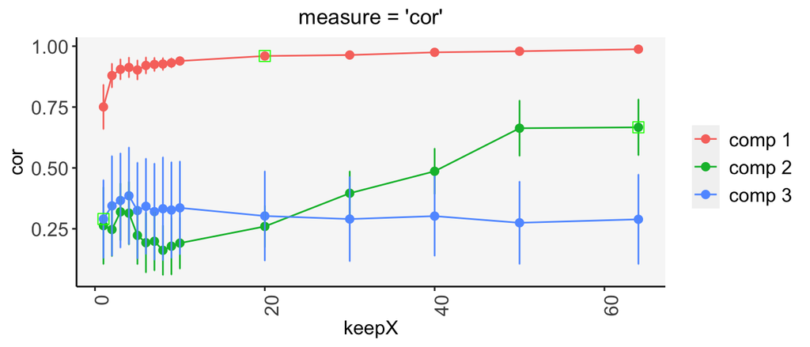

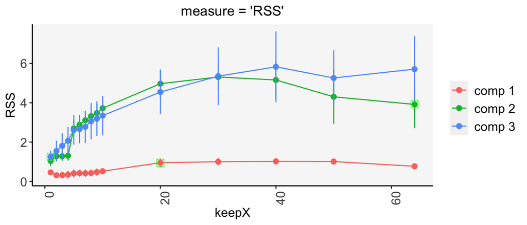

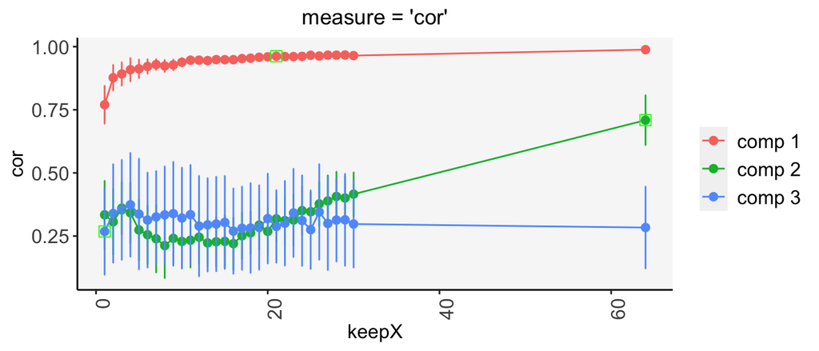

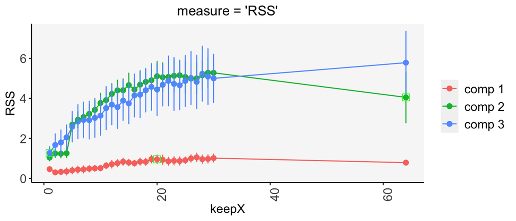

##### Y-variables

Tuning suggested 3 - 4 Y variables on component 1 and 1 - 1 Y variables on component 2. Since the Y space is not very large (8 variables), all will be used in analysis.

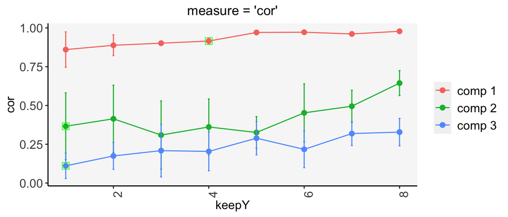

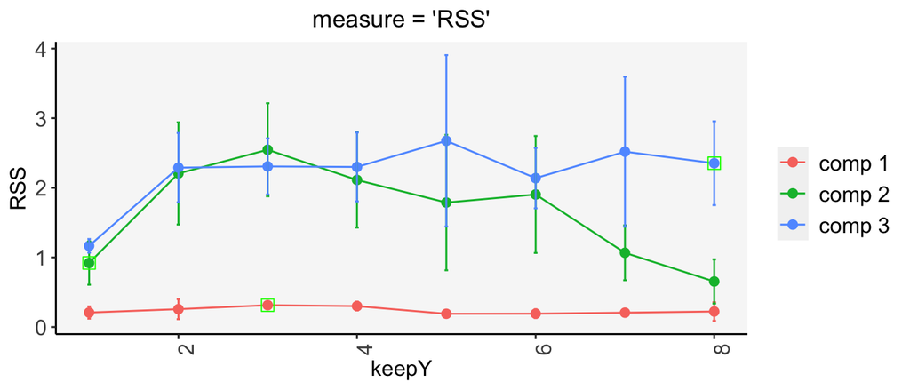

Thus, the following numbers variables will be used. Note that for X, component 1 is reduced from the RSS suggested value (20) to 14 as this it the first lower maximum and does not differ much in RSS value.

| space | component | features |
| --- | --- | --- |
| X | 1 | 14 |
| X | 2 | 2 |
| Y | 1 | 8 |
| Y | 2 | 8 |

### Run SPLS

Using the parameters determined above, run the final SPLS regression.

```r
result.spls <- spls(X,Y,
                    keepX = c(14, 2),
                    keepY = c(8,8),
                    ncomp = 2, mode = "regression")

#Save
save(spls, result.spls, file="results/PLS/SPLS.RData")
```

This results in the following variables across 2 components.

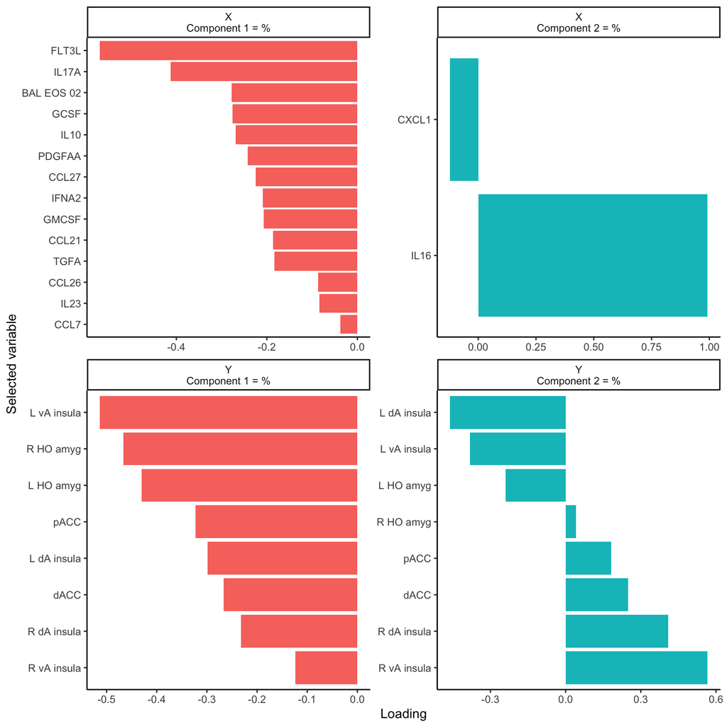

Correlations within SPLS

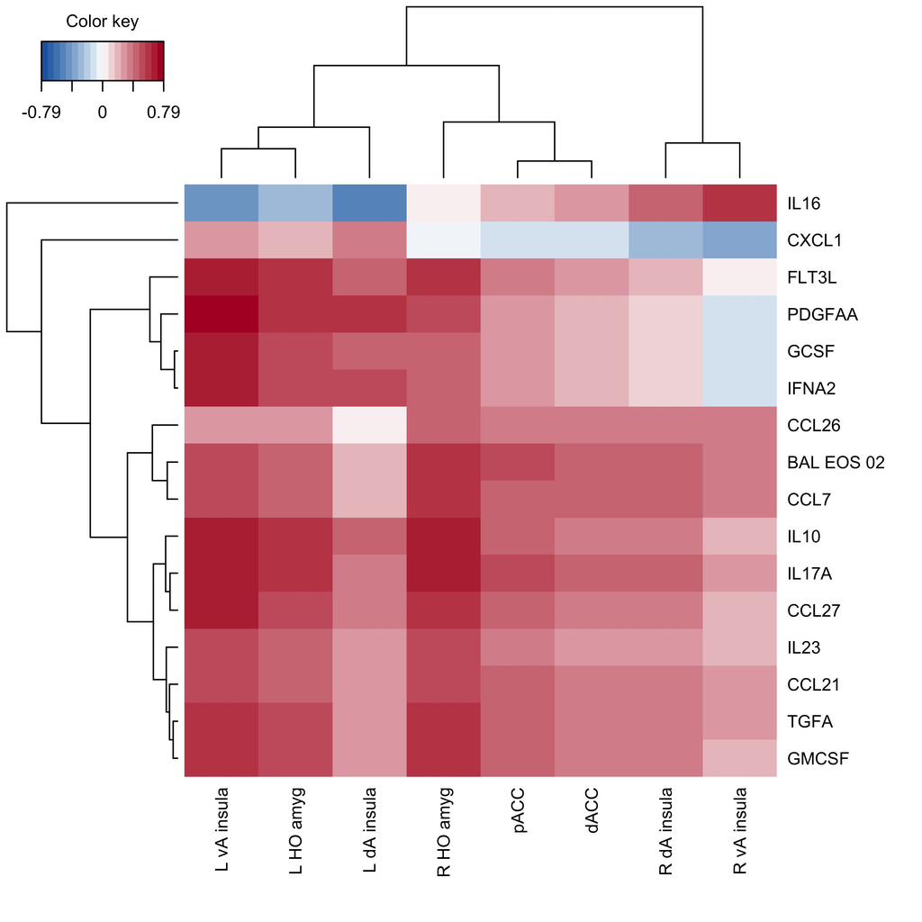

Correlation of PCs

|  | Y comp1 | Y comp2 |
| --- | --- | --- |
| **X** |  |  |
| comp1 | 0.6966072 | 0.0000000 |
| comp2 | 0.2196406 | 0.9064403 |

### Enrichment

Determine Broad term enrichment in sPLS selected genes and proteins in the STRING network.

```r
gene.list <- list()
#Main STRING cluster
gene.list[["STRING.cluster"]] <- read_csv("publication/STRING.genes.csv") %>%
  distinct(gene) %>% unlist(use.names = FALSE)
```

#### Hallmark (H)

```r
H <- BIGprofiler(gene_list = gene.list,
                ID="SYMBOL",
                category = "H",
                species = "human")
H %>%
  mutate(genes = as.character(genes)) %>%
  write_csv("results/enrichment/enrich_sPLS_H.csv")
```

#### Curated gene sets (C2 CP)

```r
c2 <- BIGprofiler(gene_list = gene.list,
                ID="SYMBOL",
                category = "C2", subcategory = "CP",
                species = "human")
c2 %>%
  mutate(genes = as.character(genes)) %>%
  write_csv("results/enrichment/enrich_sPLS_C2_CP.csv")
```

#### Gene ontology (C5)

```r
c5 <- BIGprofiler(gene_list = gene.list,
                ID="SYMBOL",
                category = "C5", subcategory = "GO:BP",
                species = "human")
c5 %>%
  mutate(genes = as.character(genes)) %>%
  write_csv("results/enrichment/enrich_sPLS_C5_GO.BP.csv")
```

#### Immunologic (C7)

```r
c7 <- BIGprofiler(gene_list = gene.list,
                ID="SYMBOL",
                category = "C7",
                species = "human")
c7 %>%
  mutate(genes = as.character(genes)) %>%
  write_csv("results/enrichment/enrich_sPLS_C7.csv")
```

#### Enrichment results

Top 10 terms for each gene set group.

| gs_cat | gs_subcat | pathway | k/K | FDR |
| --- | --- | --- | --- | --- |
| C2 | CP | NABA_SECRETED_FACTORS | 0.0728863 | 0.0000038 |
| C2 | CP:KEGG | KEGG_CYTOKINE_CYTOKINE_RECEPTOR_INTERACTION | 0.0830189 | 0.0000038 |
| C2 | CP:WIKIPATHWAYS | WP_OVERVIEW_OF_PROINFLAMMATORY_AND_PROFIBROTIC_MEDIATORS | 0.1015625 | 0.0003398 |
| C2 | CP:REACTOME | REACTOME_SIGNALING_BY_INTERLEUKINS | 0.0518359 | 0.0019875 |
| C2 | CP:WIKIPATHWAYS | WP_TYROBP_CAUSAL_NETWORK_IN_MICROGLIA | 0.1269841 | 0.0056630 |
| C2 | CP:REACTOME | REACTOME_STRIATED_MUSCLE_CONTRACTION | 0.1666667 | 0.0109622 |
| C2 | CP:WIKIPATHWAYS | WP_STRIATED_MUSCLE_CONTRACTION_PATHWAY | 0.1578947 | 0.0129100 |
| C2 | CP:KEGG | KEGG_THYROID_CANCER | 0.1724138 | 0.0264803 |
| C2 | CP:KEGG | KEGG_GLIOMA | 0.1076923 | 0.0264803 |
| C2 | CP:KEGG | KEGG_ERBB_SIGNALING_PATHWAY | 0.0919540 | 0.0264803 |
| C2 | CP:WIKIPATHWAYS | WP_EGFR_TYROSINE_KINASE_INHIBITOR_RESISTANCE | 0.0952381 | 0.0264803 |
| C2 | CP:WIKIPATHWAYS | WP_ERBB_SIGNALING_PATHWAY | 0.0879121 | 0.0331264 |
| C2 | CP:BIOCARTA | BIOCARTA_CYTOKINE_PATHWAY | 0.2105263 | 0.0387188 |
| C2 | CP:REACTOME | REACTOME_REGULATION_OF_LIPID_METABOLISM_BY_PPARALPHA | 0.0750000 | 0.0395524 |
| C2 | CP:KEGG | KEGG_JAK_STAT_SIGNALING_PATHWAY | 0.0645161 | 0.0590644 |
| C2 | CP:REACTOME | REACTOME_MUSCLE_CONTRACTION | 0.0564103 | 0.0884296 |
| C2 | CP:REACTOME | REACTOME_INTERLEUKIN_4_AND_INTERLEUKIN_13_SIGNALING | 0.0720721 | 0.0884296 |
| C2 | CP:KEGG | KEGG_PROSTATE_CANCER | 0.0786517 | 0.0922886 |
| C2 | CP:PID | PID_CD8_TCR_DOWNSTREAM_PATHWAY | 0.0923077 | 0.0922886 |
| C2 | CP:WIKIPATHWAYS | WP_CYTOKINES_AND_INFLAMMATORY_RESPONSE | 0.1538462 | 0.0922886 |
| C2 | CP:PID | PID_INTEGRIN2_PATHWAY | 0.1379310 | 0.1083753 |
| C2 | CP:PID | PID_TCR_RAS_PATHWAY | 0.2142857 | 0.1083753 |
| C2 | CP:REACTOME | REACTOME_PROLONGED_ERK_ACTIVATION_EVENTS | 0.2142857 | 0.1083753 |
| C2 | CP:WIKIPATHWAYS | WP_PLURIPOTENT_STEM_CELL_DIFFERENTIATION_PATHWAY | 0.1041667 | 0.1083753 |
| C2 | CP:WIKIPATHWAYS | WP_NONGENOMIC_ACTIONS_OF_125_DIHYDROXYVITAMIN_D3 | 0.0845070 | 0.1083753 |
| C2 | CP:WIKIPATHWAYS | WP_PI3KAKT_SIGNALING_PATHWAY | 0.0434783 | 0.1083753 |
| C2 | CP:KEGG | KEGG_ASTHMA | 0.1333333 | 0.1122902 |
| C2 | CP:REACTOME | REACTOME_NEGATIVE_REGULATION_OF_FLT3 | 0.2000000 | 0.1213515 |
| C2 | CP:KEGG | KEGG_CHEMOKINE_SIGNALING_PATHWAY | 0.0529101 | 0.1320664 |
| C2 | CP:WIKIPATHWAYS | WP_NETWORK_MAP_OF_SARSCOV2_SIGNALING_PATHWAY | 0.0497738 | 0.1320664 |

[output cut: 105 more lines]